# Creating a spaces.rds with H3 data

# Introduction

# 1. Organize your data

## 1.1 Using `data.frames`

To be able to create an `h3` type spaces, users must have their data organized in a `h3_list`, which consists of a name list of `data.frames`. Each element of the the list must represent one variable. In each `data.frame`, three columns are mandatory:

- “h3_address”: a set of H3 cells addresses
- “x”: the x coordinate of the cell’s centroid
- “y”: the y coordinate of the cell’s centroid

Obtaining an H3 cells’ centroids is easy using the `h3jsr` package, all is needed is a vector of cells addresses:

```r
h3jsr::cell_to_point(c("8166fffffffffff", "81663ffffffffff"), simple = F)
```

```
Simple feature collection with 2 features and 1 field
Geometry type: POINT
Dimension:     XY
Bounding box:  xmin: -75.52986 ymin: 1.437909 xmax: -74.83302 ymax: 8.982982
Geodetic CRS:  WGS 84
       h3_address                   geometry
1 8166fffffffffff POINT (-75.52986 1.437909)
2 81663ffffffffff POINT (-74.83302 8.982982)
```

All of the other columns in each `data.frame` must represent the value of the respective variable at a given timestep. Below is an example of how a `h3_list` should look like:

```r
head(h3_list)
```

|  | h3_address | ts_1 | ts_2 | ts_3 | ts_4 | ts_5 | x | y |
| --- | --- | --- | --- | --- | --- | --- | --- | --- |
| 1 | 8166fffffffffff | 23.864286 | 25.062866 | 25.101040 | 25.437834 | 18.530773 | -75.52986 | 1.437909363 |
| 2 | 81663ffffffffff | 29.117130 | 29.326101 | 29.148424 | 29.068031 | 21.802000 | -74.83302 | 8.982981657 |
| 3 | 81677ffffffffff | 28.413494 | 29.193842 | 29.227274 | 29.654116 | 22.799784 | -68.05375 | 11.537128368 |
| 4 | 815f7ffffffffff | 28.429352 | 28.801939 | 28.914368 | 29.175327 | 21.026901 | -62.10131 | 7.595720344 |
| 5 | 81667ffffffffff | 29.319040 | 29.840782 | 29.970201 | 30.206596 | 21.666615 | -68.55106 | 4.411665393 |
| 6 | 818f7ffffffffff | 24.280554 | 24.593023 | 24.671648 | 24.848705 | 19.058037 | -76.26390 | -6.559042788 |
| 7 | 818a7ffffffffff | 28.898159 | 29.400438 | 29.598757 | 29.931284 | 23.490366 | -69.07532 | -3.245939610 |
| 8 | 818afffffffffff | 28.940624 | 29.600868 | 29.933388 | 30.375282 | 23.002592 | -62.45043 | 0.008323045 |
| 9 | 818b7ffffffffff | 27.237026 | 27.702999 | 27.854113 | 28.145260 | 23.004581 | -69.62869 | -11.199875898 |
| 10 | 818a3ffffffffff | 27.599981 | 28.035788 | 28.153667 | 28.413891 | 23.033892 | -62.80594 | -7.716675190 |

[output cut: 30 more lines]

```
NA
```

## 1.2 Using rasters

Most environmental data is available in rasters. For that reason, to create an `h3_list`, users probably will need to:

- 1. Decide which are the H3 cells of interest
- 2. Extract values for this cells from rasters
- 3. Organize the data in a named list

To ease this process, `spac3tools` features the function `data_raster_to_h3`, which transform a list of rasters in a list of data.frames to be used within `create_spaces_h3`. The function takes as inputs:

- `h3_address`: a set of H3 cells’ address
- `res`: an H3 resolution
- `raster_list`: a named list of rasters in the same format as used in `gen3sis2::create_spaces_raster`

Users must provide `h3_address` *or* `res`. In case of a set of H3 addresses is passed, the function will extract data from the rasters at the centroid of the cells. If a resolution is provided, the function will try to extract data for *all global cells at the given resolution*. The `raster_list` follows the same format as the one used in `gen3sis::create_spaces_raster`.

Let’s follow an example. First, load some raster data:

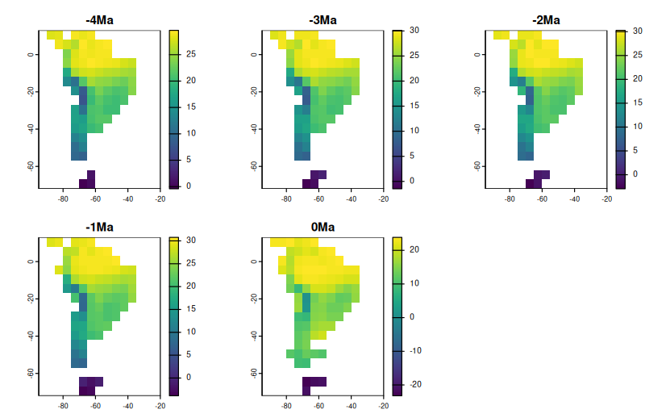

Now, we can organize it in a `raster_list`:

```r
raster_list <- list(
  temperature = temperature_raster
)
raster_list
```

```
$temperature
class       : SpatRaster
size        : 17, 15, 5  (nrow, ncol, nlyr)
resolution  : 5, 5  (x, y)
extent      : -95, -20, -72, 13  (xmin, xmax, ymin, ymax)
coord. ref. : lon/lat WGS 84 (EPSG:4326)
source      : temperature.tiff
names       :       -4Ma,      -3Ma,      -2Ma,      -1Ma,       0Ma
min values  : -0.4119726, -1.468547, -2.945441, -3.883233, -23.21881
max values  : 29.6100998, 30.110872, 30.278172, 30.766106,  23.85205
```

Now, will use a set of H3 addresses at resolution 1 that encompasses the South America continent, and create a concice `h3_list`:

```r
south_america_cells <- c(
  "8166fffffffffff", "81663ffffffffff", "81677ffffffffff", "815f7ffffffffff",
  "81667ffffffffff", "818f7ffffffffff", "818a7ffffffffff", "818afffffffffff",
  "818b7ffffffffff", "818a3ffffffffff", "815f3ffffffffff", "818abffffffffff",
  "81807ffffffffff", "81803ffffffffff", "8181bffffffffff", "81813ffffffffff",
  "81a8bffffffffff", "81817ffffffffff", "818bbffffffffff", "81a8fffffffffff",
  "818b3ffffffffff", "81a87ffffffffff", "81a83ffffffffff", "81a93ffffffffff",
  "81c2fffffffffff", "81c23ffffffffff", "81c37ffffffffff", "81b2fffffffffff",
  "81cebffffffffff", "81b27ffffffffff", "81a97ffffffffff", "81b37ffffffffff",
  "81b23ffffffffff", "81b33ffffffffff", "818e7ffffffffff", "81c33ffffffffff",
  "81cfbffffffffff", "81df7ffffffffff", "818f3ffffffffff", "8166bffffffffff")

h3_list <- data_raster_to_h3(h3_address = south_america_cells, raster_list = raster_list)

h3_list
```

|  | h3_address | ts_1 | ts_2 | ts_3 | ts_4 | ts_5 | x | y |
| --- | --- | --- | --- | --- | --- | --- | --- | --- |
| 1 | 8166fffffffffff | 23.864286 | 25.062866 | 25.101040 | 25.437834 | 18.530773 | -75.52986 | 1.437909363 |
| 2 | 81663ffffffffff | 29.117130 | 29.326101 | 29.148424 | 29.068031 | 21.802000 | -74.83302 | 8.982981657 |
| 3 | 81677ffffffffff | 28.413494 | 29.193842 | 29.227274 | 29.654116 | 22.799784 | -68.05375 | 11.537128368 |
| 4 | 815f7ffffffffff | 28.429352 | 28.801939 | 28.914368 | 29.175327 | 21.026901 | -62.10131 | 7.595720344 |
| 5 | 81667ffffffffff | 29.319040 | 29.840782 | 29.970201 | 30.206596 | 21.666615 | -68.55106 | 4.411665393 |
| 6 | 818f7ffffffffff | 24.280554 | 24.593023 | 24.671648 | 24.848705 | 19.058037 | -76.26390 | -6.559042788 |
| 7 | 818a7ffffffffff | 28.898159 | 29.400438 | 29.598757 | 29.931284 | 23.490366 | -69.07532 | -3.245939610 |
| 8 | 818afffffffffff | 28.940624 | 29.600868 | 29.933388 | 30.375282 | 23.002592 | -62.45043 | 0.008323045 |
| 9 | 818b7ffffffffff | 27.237026 | 27.702999 | 27.854113 | 28.145260 | 23.004581 | -69.62869 | -11.199875898 |
| 10 | 818a3ffffffffff | 27.599981 | 28.035788 | 28.153667 | 28.413891 | 23.033892 | -62.80594 | -7.716675190 |

[output cut: 30 more lines]

```
NA
```

It is also possible to provide just an H3 resolution. In this case, the function will try to extract data for all global cells, but will use only the ones within rasters’ extent:

```r
h3_list_res
```

|  | h3_address | ts_1 | ts_2 | ts_3 | ts_4 | ts_5 | x | y |
| --- | --- | --- | --- | --- | --- | --- | --- | --- |
| 1 | 81567ffffffffff | NA | NA | NA | NA | NA | -27.94705 | 10.986366200 |
| 2 | 8156bffffffffff | NA | NA | NA | NA | NA | -41.71030 | 11.572352053 |
| 3 | 8156fffffffffff | NA | NA | NA | NA | NA | -34.76126 | 7.495025848 |
| 4 | 815e3ffffffffff | NA | NA | NA | NA | NA | -55.49906 | 11.509775527 |
| 5 | 815f3ffffffffff | 29.036757 | 29.744347 | 30.014114 | 30.323006 | 23.151707 | -55.79466 | 3.839857557 |
| 6 | 815f7ffffffffff | 28.429352 | 28.801939 | 28.914368 | 29.175327 | 21.026901 | -62.10131 | 7.595720344 |
| 7 | 815fbffffffffff | NA | NA | NA | NA | NA | -48.81720 | 7.763963640 |
| 8 | 81663ffffffffff | 29.117130 | 29.326101 | 29.148424 | 29.068031 | 21.802000 | -74.83302 | 8.982981657 |
| 9 | 81667ffffffffff | 29.319040 | 29.840782 | 29.970201 | 30.206596 | 21.666615 | -68.55106 | 4.411665393 |
| 10 | 8166bffffffffff | 28.797161 | 29.524809 | NA | NA | NA | -82.01090 | 6.103462406 |

[output cut: 90 more lines]

```
NA
```